# Usaldusvahemiku praktikum

Indrek Soidla

2023-09-26

## Harjutus 1

Täiendades allolevat `ggplot`-käsu koodi, koosta punktdiagramm, kus x-teljel on viis regiooni ja y-teljel tunnuse punktidega esitatud tunnuse `lkredcc` keskmised.

```r
library(haven)
library(tidyverse)
# install.packages("meantables")
library(meantables)

r8 <- read_spss("data/ESS8e02_2.sav")
ee8 <- r8 %>%
  filter(cntry == "EE") %>%
  select(lkredcc, region, pspwght)

ee8$region <- dplyr::recode(as.factor(ee8$region),
                     "EE001" = "Põhja-Eesti",
                     "EE004" = "Lääne-Eesti",
                     "EE006" = "Kesk-Eesti",
                     "EE007" = "Kirde-Eesti",
                     "EE008" = "Lõuna-Eesti")

lk_95 <- ee8 %>%
  group_by(region) %>%
  mean_table(lkredcc)

lk_95
```

```
## # A tibble: 5 × 11
##   response_var group_var group_cat      n  mean    sd    sem   lcl   ucl min
##   <chr>        <chr>     <fct>      <int> <dbl> <dbl>  <dbl> <dbl> <dbl> <dbl+l>
## 1 lkredcc      region    Põhja-Ees…   792  4.98  2.34 0.0831  4.82  5.15 0 [Not…
## 2 lkredcc      region    Lääne-Ees…   232  4.57  2.41 0.158   4.26  4.88 0 [Not…
## 3 lkredcc      region    Kesk-Eesti   181  4.53  2.67 0.199   4.14  4.92 0 [Not…
## 4 lkredcc      region    Kirde-Ees…   185  4.08  2.43 0.178   3.73  4.43 0 [Not…
## 5 lkredcc      region    Lõuna-Ees…   515  4.61  2.46 0.108   4.4   4.82 0 [Not…
## # ℹ 1 more variable: max <dbl+lbl>
```

```r
ggplot(lk_95, aes(x = _____, y = _____)) +
  geom______()
```

Punktdiagramm peaks välja nägema selline:

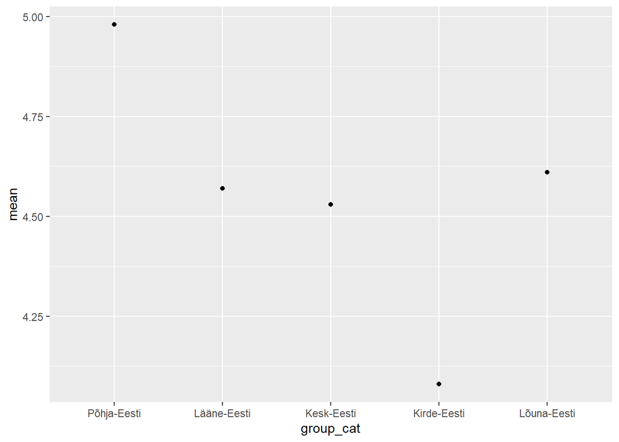

## Harjutus 2

Täienda allolevat koodi, et lisada punktidagrammile n-ö vurrud, mis näitaksid diagrammil olevate aritmeetiliste keskmiste usaldusvahemikke. Saad need lisada funktsiooniga `geom_errorbar`.

```r
ggplot(lk_95, aes(x = _____, y = _____)) +
  geom______() +
  geom_errorbar(aes(ymin = _____, ymax = _____), width = 0.1)
```

Vurrudega punktdiagrammi nimetatakse ka vahemikdiagrammiks, antud juhul peaks see välja nägema selline:

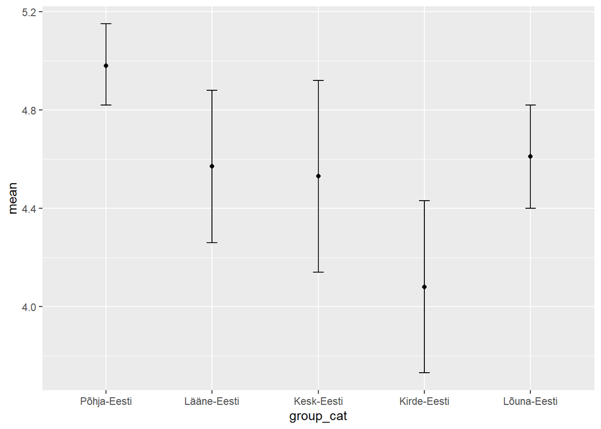

## Harjutus 3

Vastajatelt küsiti ka, kui tõenäoline on, et piisaval hulgal valitsusi rakendab meetmeid kliimamuutuse vähendamiseks (tunnus `gvsrdcc`).

Millised on selle arvamuse keskmise punkthinnangud ja vahemikhinnangud haridustasemeti? Esitage vahemikhinnangud ka vahemikdiagrammil.

Kuidas neid vahemikhinnanguid õigesti tõlgendada?

Kodeerige haridustaseme tunnus ümber nelja kategooriasse.

```r
ee8a <- r8 %>%
  filter(cntry == "EE") %>%
  select(gvsrdcc, edulvlb, pspwght)

ee8a <- ee8a %>%
  mutate(har = case_when(edulvlb <= 213 ~ "Kuni põhiharidus",
                         edulvlb == 313 ~ "Keskharidus",
                         edulvlb > 213 & edulvlb < 600 ~ "Kutseharidus",
                         edulvlb >= 600 ~ "Kõrgharidus"))

library(forcats)
ee8a$har <- fct_relevel(ee8a$har,
                        "Kuni põhiharidus",
                        "Kutseharidus",
                        "Keskharidus",
                        "Kõrgharidus")
```

## Harjutus 4

Võttes aluseks eelmise ülesande lahenduse, mida saab väita nende usaldusvahemike võrdlemise põhjal? Milliste gruppide vahel saab populatsiooni tasandil väita erinevuste esinemist usaldusnivool 95%? Kus tarvis, arvutage keskmiste erinevuste usaldusvahemikud.

## Harjutus 5

Tehke harjutused 3 ja 4 läbi, võttes arvesse kaale. Kuivõrd tulemused erinevad?

## Harjutus 6

Kas samal ajal kui RE reiting augusti ja septembri võrdluses tõusis, saame väita, et KE reiting langes?

Praktikumislaididel oleva RE reitingute võrdluse kood, mida saate ülesande lahendamisel kasutada:

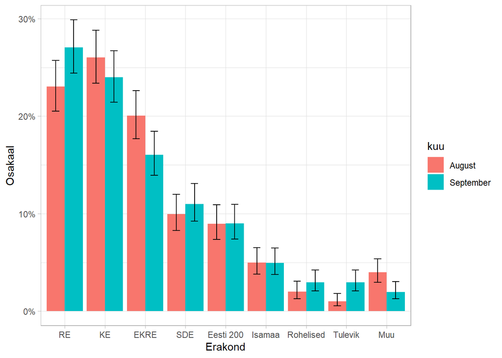

```r
erakond <- rep(c("RE", "KE", "EKRE", "SDE", "Eesti 200", "Isamaa",
                 "Rohelised", "Tulevik", "Muu"), 2)
reiting <- data.frame(erakond)
reiting$poolehoid <- c(0.23, 0.26, 0.20, 0.10, 0.09, 0.05, 0.02,
                       0.01, 0.04, 0.27, 0.24, 0.16, 0.11, 0.09,
                       0.05, 0.03, 0.03, 0.02)
reiting$kuu <- c(rep("August", 9), rep("September", 9))

reiting <- reiting %>%
  mutate(poolehoid_n = ifelse(kuu == "August",
                              poolehoid * 1003,
                              poolehoid * 1010) %>%
           round())

library(DescTools)

poolehoid_aug <- reiting %>%
  filter(kuu == "August") %>%
  pull(poolehoid_n) %>%
  MultinomCI(conf.level = 0.95, method = "wilson")

poolehoid_sept <- reiting %>%
  filter(kuu == "September") %>%
  pull(poolehoid_n) %>%
  MultinomCI(conf.level = 0.95, method = "wilson")

poolehoid_ci <- rbind(poolehoid_aug, poolehoid_sept) %>%
  as.data.frame()

poolehoid_ci$erakond <- reiting$erakond
poolehoid_ci$kuu <- reiting$kuu

library(scales)
ggplot(poolehoid_ci, aes(x = erakond, y = est, fill = kuu)) +
  geom_bar(stat = "identity", position = "dodge", width = 0.9) +
  geom_errorbar(aes(ymin = lwr.ci, ymax = upr.ci), position = position_dodge2(width = 0.6, padding = 0.6), color = "black") +
  scale_y_continuous(labels = scales::percent_format(accuracy = 1L)) +
  scale_x_discrete(limits = poolehoid_ci$erakond[1:9]) +
  labs(x = "Erakond",
       y = "Osakaal") +
  theme_light()
```

$$Z = \frac{\hat{p}_1 -
\hat{p}_2}{\sqrt{\hat{p}(1-\hat{p})(\frac{1}{n_1}+\frac{1}{n_2})}}$$

- $\hat{p}_1$ – esimese grupi osakaal esimesest valimist $(n_1)$
- $\hat{p}_2$ – teise grupi osakaal teisest valimist $(n_2)$
- $\hat{p}$ – mõlema grupi osakaal mõlema valimi peale kokku: $\frac{\hat{p}_1 + \hat{p}_2}{n_1+n_2}$
- $n_1$ – esimese valimi suurus
- $n_2$ – teise valimi suurus

```r
ind_arv_gruppides <- reiting %>%
  filter(erakond == "RE") %>%
  pull(poolehoid_n)


n1 <- reiting %>%
  filter(kuu == "August") %>%
  pull(poolehoid_n) %>%
  sum()

n2 <- reiting %>%
  filter(kuu == "September") %>%
  pull(poolehoid_n) %>%
  sum()

prop.test(ind_arv_gruppides, c(n1, n2), correct = FALSE)
```

```
##
##  2-sample test for equality of proportions without continuity correction
##
## data:  ind_arv_gruppides out of c(n1, n2)
## X-squared = 4.3416, df = 1, p-value = 0.03719
## alternative hypothesis: two.sided
## 95 percent confidence interval:
##  -0.078075315 -0.002436371
## sample estimates:
##    prop 1    prop 2
## 0.2303091 0.2705649
```

## Harjutus 7

- KE ja RE reitingute erinevust 2020 septembris väita ei saanud. Kas 2020 augustis oli RE edumaa siiski statistilisest veast suurem, st sai väita RE kõrgemat reitingut KE-st?
- Osakaalude erinevuse usalduspiiride valem (Scott ja Seber 1983):

$$p_1 - p_2 >= \hat{p}_1 - \hat{p}_2 -
z_{1 -
\frac{\alpha}{2}}\sqrt{\frac{\hat{p}_1+\hat{p}_2-(\hat{p}_1-\hat{p}_2)^2}{n}}$$

$$p_1 - p_2 <= \hat{p}_1 - \hat{p}_2 +
z_{1 -
\frac{\alpha}{2}}\sqrt{\frac{\hat{p}_1+\hat{p}_2-(\hat{p}_1-\hat{p}_2)^2}{n}}$$

- $p_1, p_2$ – esimese ja teise grupi osakaal populatsioonis
- $\hat{p}_1, \hat{p}_2$ – esimese ja teise grupi osakaal valimis
- $z_{1 - \frac{\alpha}{2}}$ – standardiseeritud normaaljaotuse $1 - \frac{\alpha}{2}$-kvantiil
- $n$ – valimi suurus

Praktikumislaididel olev RE ja KE septembrireitingute võrdlus, mida saate ülesande lahendamisel kasutada:

- RE septembrikuu reiting

```r
p1 <- reiting %>%
  filter(erakond == "RE" & kuu == "September") %>%
  pull(poolehoid)
```

- KE septembrikuu reiting

```r
p2 <- reiting %>%
  filter(erakond == "KE" & kuu == "September") %>%
  pull(poolehoid)
```

- Reitingute erinevus valimis

```r
p1 - p2
```

```
## [1] 0.03
```

- Alumine usalduspiir: $p_1 - p_2 >= \hat{p}_1 - \hat{p}_2 - z_{1 - \frac{\alpha}{2}}\sqrt{\frac{\hat{p}_1+\hat{p}_2-(\hat{p}_1-\hat{p}_2)^2}{n}}$

```r
p1 - p2 - 1.96 * sqrt((p1 + p2 - (p1 - p2)^2) / n2)
```

```
## [1] -0.01402628
```

- Ülemine usalduspiir: $p_1 - p_2 <= \hat{p}_1 - \hat{p}_2 + z_{1 - \frac{\alpha}{2}}\sqrt{\frac{\hat{p}_1+\hat{p}_2-(\hat{p}_1-\hat{p}_2)^2}{n}}$

```r
p1 - p2 + 1.96 * sqrt((p1 + p2 - (p1 - p2)^2) / n2)
```

```
## [1] 0.07402628
```